# projet acp

## 3. Interprétation de la carte des variables

la matrice des coordonees des variables :

```r
res.pca$var$coord
```

```
##                            Dim.1       Dim.2        Dim.3        Dim.4
## game of thrones        0.5497347 -0.51211017  0.500847259  0.006359306
## breaking bad           0.7938477 -0.11787867  0.156232753 -0.239863368
## the walking dead       0.2666909  0.25697656  0.380094035 -0.140508116
## La casa de papel       0.2622175  0.04850427 -0.117979167 -0.298110290
## friends                0.2865245 -0.31280690 -0.443497761  0.603578097
## how i met your mother  0.5941951 -0.41028444 -0.371132373  0.226178026
## sherlock               0.4724387  0.10048512 -0.474896193 -0.507057601
## attack on titans       0.3539249  0.15519691  0.329818824 -0.188868811
## prison break           0.6520438  0.11251116 -0.064119236  0.355806147
## stranger things        0.2532459  0.80615269 -0.071543063 -0.004476760
## vikings                0.3620805  0.09214515  0.732418614  0.163772321
## dark                   0.5390088  0.40704767 -0.372101514 -0.291286105
## peaky blinders         0.3876043  0.34257400 -0.009161998  0.662455944
## you                   -0.2315969  0.59673179  0.067850451  0.381287267
##                             Dim.5
## game of thrones        0.04610470
## breaking bad          -0.11308017
## the walking dead       0.50379736
## La casa de papel       0.64457773
## friends                0.27497561
## how i met your mother  0.11724532
## sherlock               0.12425712
## attack on titans       0.11472031
## prison break          -0.17985321
## stranger things       -0.22977293
## vikings               -0.11627125
## dark                  -0.23980670
## peaky blinders        -0.06954692
## you                    0.48765485
```

la matrice des coordonees des cos carees des variables :

```r
res.pca$var$cos2
```

```
##                            Dim.1       Dim.2        Dim.3        Dim.4
## game of thrones       0.30220820 0.262256825 0.2508479764 4.044077e-05
## breaking bad          0.63019415 0.013895381 0.0244086732 5.753444e-02
## the walking dead      0.07112403 0.066036952 0.1444714754 1.974253e-02
## La casa de papel      0.06875804 0.002352664 0.0139190839 8.886975e-02
## friends               0.08209628 0.097848155 0.1966902637 3.643065e-01
## how i met your mother 0.35306787 0.168333323 0.1377392381 5.115650e-02
## sherlock              0.22319832 0.010097260 0.2255263940 2.571074e-01
## attack on titans      0.12526282 0.024086080 0.1087804564 3.567143e-02
## prison break          0.42516115 0.012658762 0.0041112764 1.265980e-01
## stranger things       0.06413349 0.649882165 0.0051184099 2.004138e-05
## vikings               0.13110226 0.008490729 0.5364370268 2.682137e-02
## dark                  0.29053049 0.165687809 0.1384595370 8.484760e-02
## peaky blinders        0.15023707 0.117356944 0.0000839422 4.388479e-01
## you                   0.05363714 0.356088830 0.0046036837 1.453800e-01
##                             Dim.5
## game of thrones       0.002125643
## breaking bad          0.012787125
## the walking dead      0.253811776
## La casa de papel      0.415480449
## friends               0.075611586
## how i met your mother 0.013746465
## sherlock              0.015439833
## attack on titans      0.013160749
## prison break          0.032347179
## stranger things       0.052795599
## vikings               0.013519005
## dark                  0.057507255
## peaky blinders        0.004836774
## you                   0.237807255
```

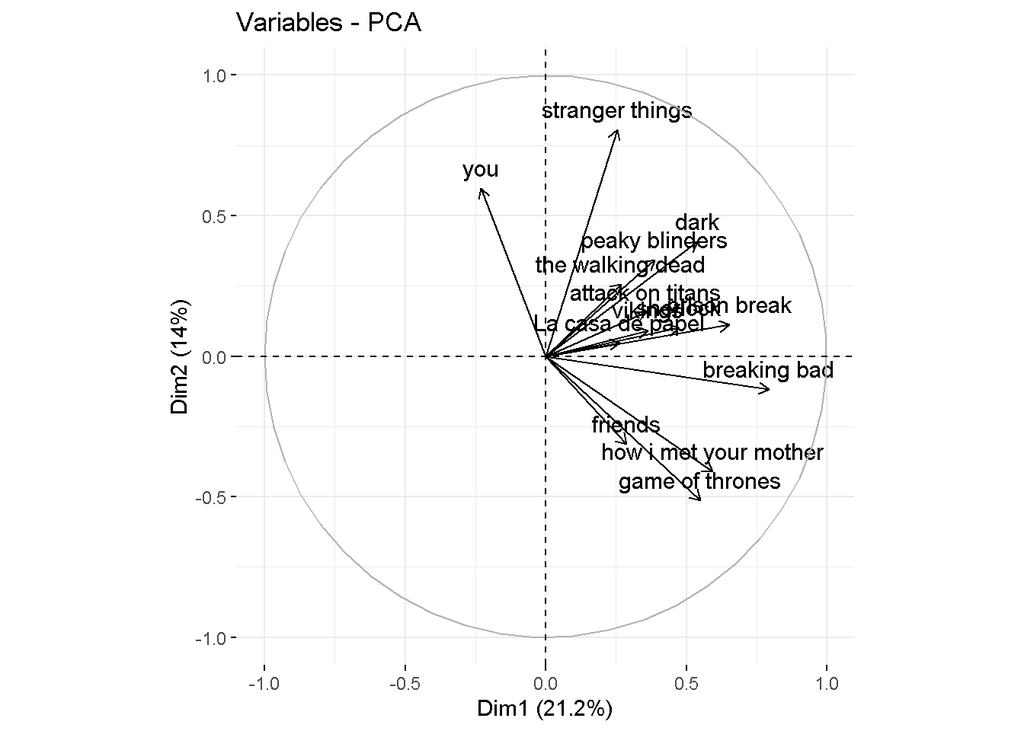

```r
fviz_pca_var(res.pca)
```

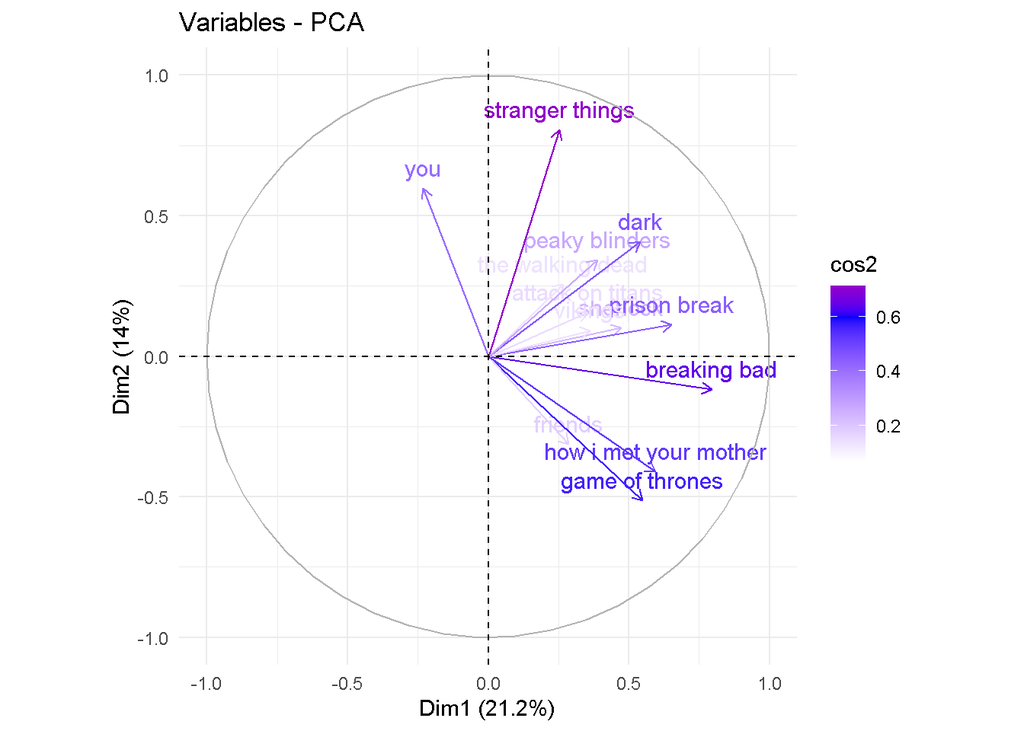

```r
fviz_pca_var(res.pca, col.var="cos2") +
  scale_color_gradient2(low="white", mid="blue",
                        high="red", midpoint=0.6) +
 theme_minimal()
```

Interprétation de cette première carte des variables (i.e. axes 1 et 2) :

d’apres les contibutions des variables et la carte des variables on a :

les variables “breaking bad” et “prison break” sont positivement corrélée avec l’axe 1 tandis que les variables le series”stranger things est faibelement corrélée avec cet et la variable “you” est faiblement corrolee avec cet axe ainsi le premier axe correspend a l’axe **” suspense “**

## 4. Interprétation de la carte des individus

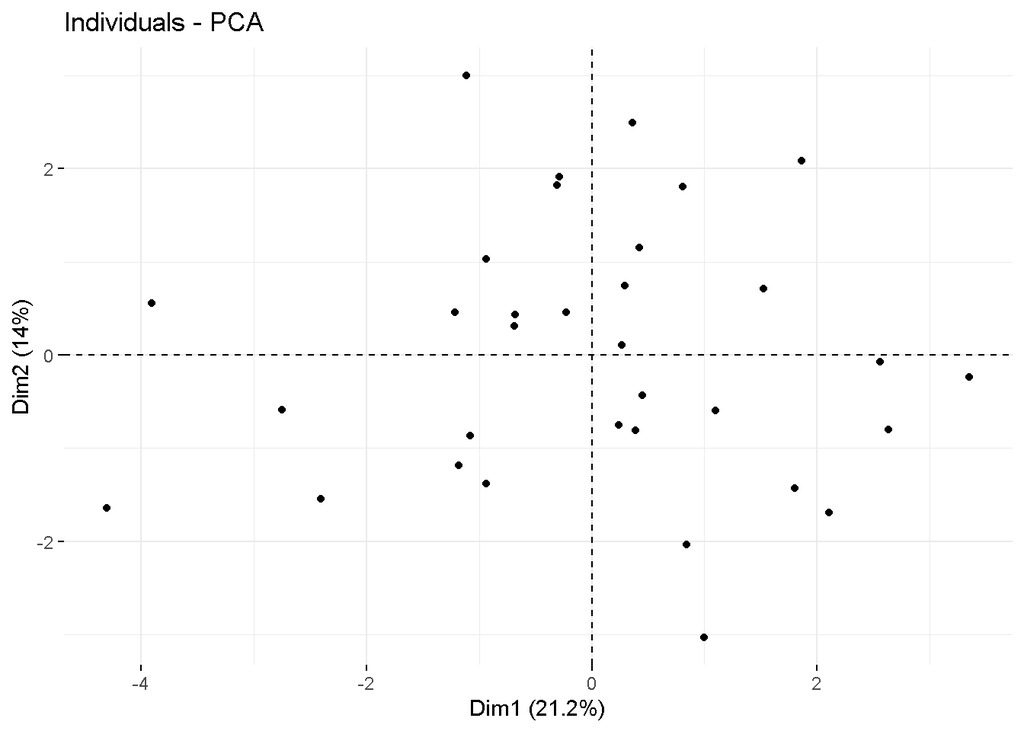

```r
fviz_pca_ind(res.pca,geom = "point",col.ind.sup = 'gray')
```

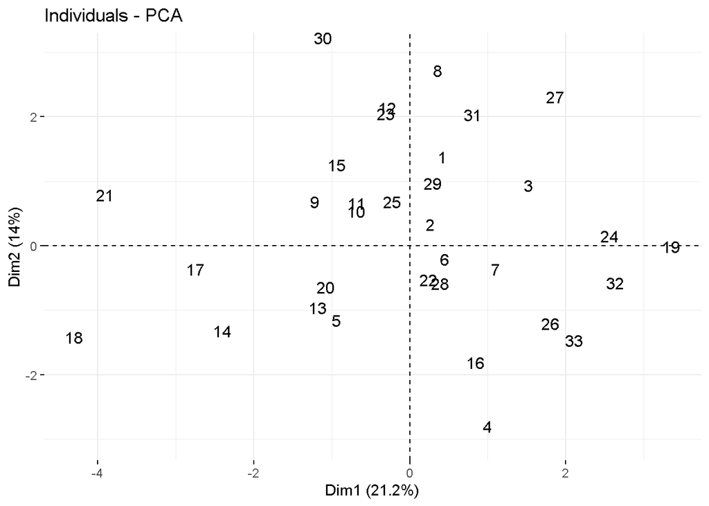

```r
fviz_pca_ind(res.pca,geom = "text",col.ind.sup = 'gray')
```

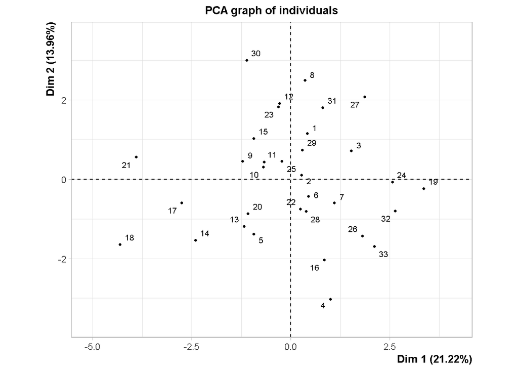

```r
plot.PCA(res.pca, axes=c(1, 2), choix="ind",cex=0.7)
```

## 6 classification des individus

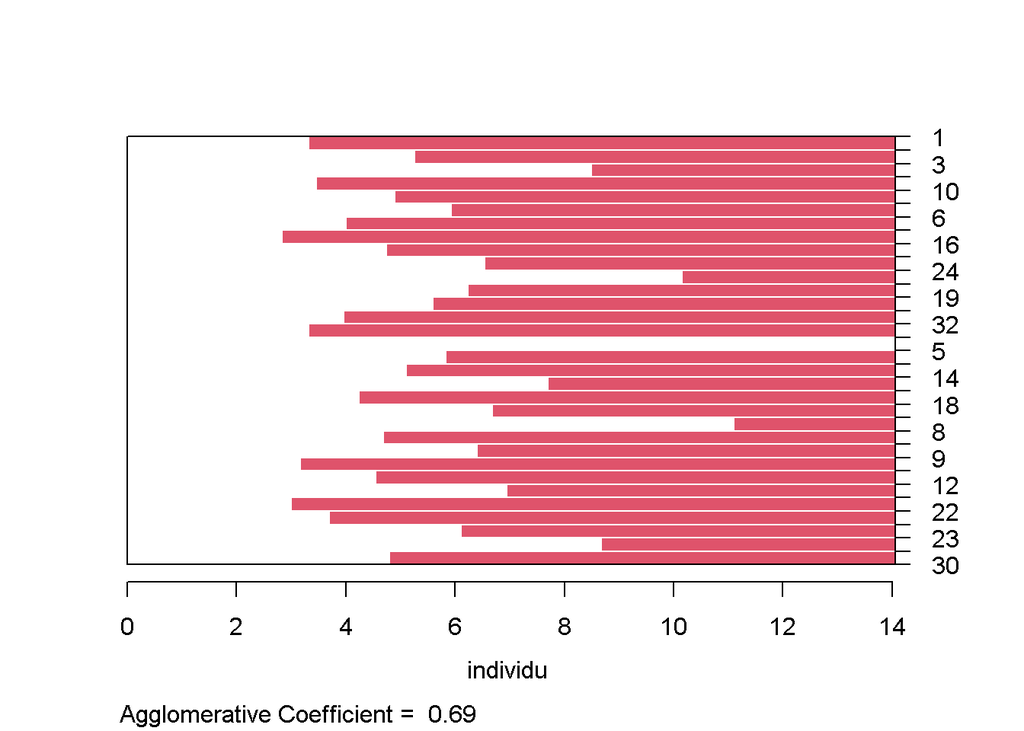

```r
library(cluster)
library(FactoMineR)
x=reponses[,22:35]
classif<-agnes(X, method="ward")

plot(classif,xlab="individu",main="")
```

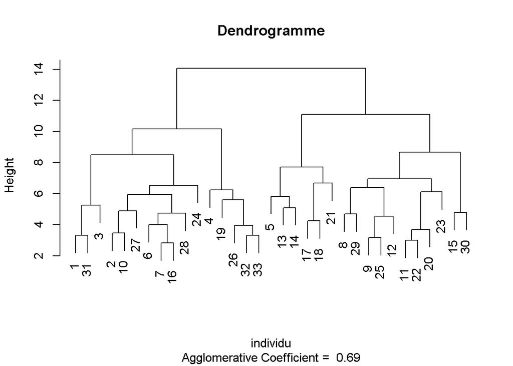

```r
title("Dendrogramme")
```

d’apres le Dendrogramme on peut classer les individus sur 4 classes excatement comme la carte des individus l’a deja montre precedement , ainsi cutree doit etre sur le nivaeu 4

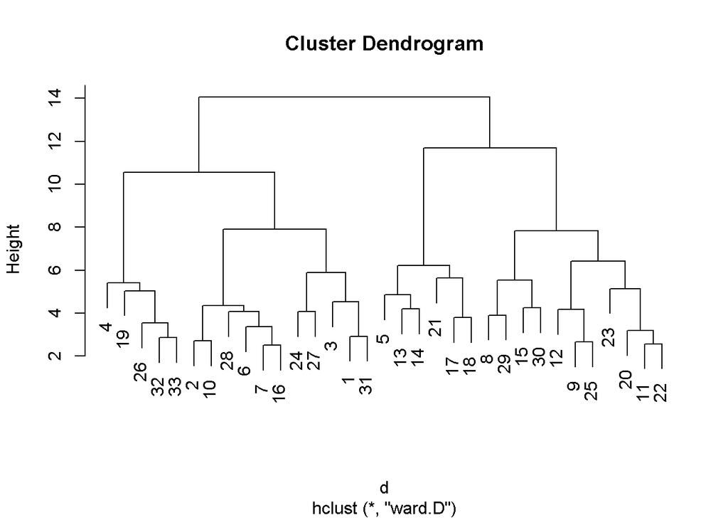

```r
d=dist(scale(X),method = "euclidian")
hc1=hclust(d,method = "ward.D")
plot(hc1)
```

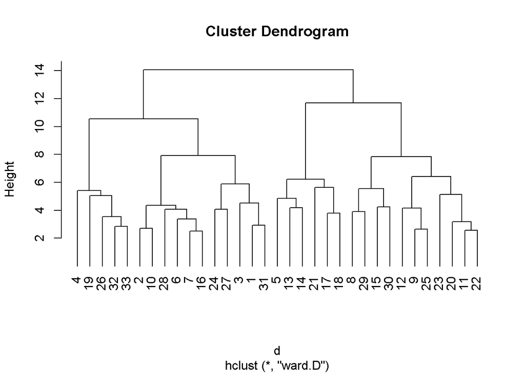

```r
plot(hc1, hang = -1)
```